# R Exercises - COVID

2020-10-30

The COVID-19 pandemics is a lot of bad things, but it’s also a source of data to play with…

Here we’re gonna use the data gathered by the John’s Hopkins Hospital and published on [GitHub](https://github.com/CSSEGISandData/COVID-19), for [confirmed cases](https://raw.githubusercontent.com/CSSEGISandData/COVID-19/master/csse_covid_19_data/csse_covid_19_time_series/time_series_covid19_confirmed_global.csv) and [deaths](https://raw.githubusercontent.com/CSSEGISandData/COVID-19/master/csse_covid_19_data/csse_covid_19_time_series/time_series_covid19_deaths_global.csv).

In case the links above die at some point, here is a version of these files as of April 21st, 2020:

- confirmed cases
- deaths

In fact, a [quick lookup](https://www.statsandr.com/blog/top-r-resources-on-covid-19-coronavirus/#r-shiny-apps) on the Internet will now return plenty of versions for this data, with even cleaner (tidy) versions, including country population, etc. There are even R packages to get this. The point here is to learn how to read a given dataset, clean it and use it, so we’ll stay with the JHU dataset.

# 1 Data wrangling

- First, load the `tidyverse` and `lubridate` packages

```r
library("tidyverse")
library("lubridate")
```

- Load the raw .csv files from the links above and store them in `confirmed_raw` and `deaths_raw`. You can provide `read_csv()` with an url.

```r
confirmed_raw <- read_csv("https://raw.githubusercontent.com/CSSEGISandData/COVID-19/master/csse_covid_19_data/csse_covid_19_time_series/time_series_covid19_confirmed_global.csv")

deaths_raw <- read_csv("https://raw.githubusercontent.com/CSSEGISandData/COVID-19/master/csse_covid_19_data/csse_covid_19_time_series/time_series_covid19_deaths_global.csv")

confirmed_raw %>% filter(`Country/Region` == "US")
```

```
## # A tibble: 1 x 286
##   `Province/State` `Country/Region`   Lat  Long `1/22/20` `1/23/20` `1/24/20`
##   <chr>            <chr>            <dbl> <dbl>     <dbl>     <dbl>     <dbl>
## 1 <NA>             US                  40  -100         1         1         2
## # … with 279 more variables: `1/25/20` <dbl>, `1/26/20` <dbl>, `1/27/20` <dbl>,
## #   `1/28/20` <dbl>, `1/29/20` <dbl>, `1/30/20` <dbl>, `1/31/20` <dbl>,
## #   `2/1/20` <dbl>, `2/2/20` <dbl>, `2/3/20` <dbl>, `2/4/20` <dbl>,
## #   `2/5/20` <dbl>, `2/6/20` <dbl>, `2/7/20` <dbl>, `2/8/20` <dbl>,
## #   `2/9/20` <dbl>, `2/10/20` <dbl>, `2/11/20` <dbl>, `2/12/20` <dbl>,
## #   `2/13/20` <dbl>, `2/14/20` <dbl>, `2/15/20` <dbl>, `2/16/20` <dbl>,
## #   `2/17/20` <dbl>, `2/18/20` <dbl>, `2/19/20` <dbl>, `2/20/20` <dbl>,
## #   `2/21/20` <dbl>, `2/22/20` <dbl>, `2/23/20` <dbl>, `2/24/20` <dbl>,
## #   `2/25/20` <dbl>, `2/26/20` <dbl>, `2/27/20` <dbl>, `2/28/20` <dbl>,
## #   `2/29/20` <dbl>, `3/1/20` <dbl>, `3/2/20` <dbl>, `3/3/20` <dbl>,
## #   `3/4/20` <dbl>, `3/5/20` <dbl>, `3/6/20` <dbl>, `3/7/20` <dbl>,
## #   `3/8/20` <dbl>, `3/9/20` <dbl>, `3/10/20` <dbl>, `3/11/20` <dbl>,
## #   `3/12/20` <dbl>, `3/13/20` <dbl>, `3/14/20` <dbl>, `3/15/20` <dbl>,
## #   `3/16/20` <dbl>, `3/17/20` <dbl>, `3/18/20` <dbl>, `3/19/20` <dbl>,
## #   `3/20/20` <dbl>, `3/21/20` <dbl>, `3/22/20` <dbl>, `3/23/20` <dbl>,
## #   `3/24/20` <dbl>, `3/25/20` <dbl>, `3/26/20` <dbl>, `3/27/20` <dbl>,
## #   `3/28/20` <dbl>, `3/29/20` <dbl>, `3/30/20` <dbl>, `3/31/20` <dbl>,
## #   `4/1/20` <dbl>, `4/2/20` <dbl>, `4/3/20` <dbl>, `4/4/20` <dbl>,
## #   `4/5/20` <dbl>, `4/6/20` <dbl>, `4/7/20` <dbl>, `4/8/20` <dbl>,
## #   `4/9/20` <dbl>, `4/10/20` <dbl>, `4/11/20` <dbl>, `4/12/20` <dbl>,
## #   `4/13/20` <dbl>, `4/14/20` <dbl>, `4/15/20` <dbl>, `4/16/20` <dbl>,
## #   `4/17/20` <dbl>, `4/18/20` <dbl>, `4/19/20` <dbl>, `4/20/20` <dbl>,
## #   `4/21/20` <dbl>, `4/22/20` <dbl>, `4/23/20` <dbl>, `4/24/20` <dbl>,
## #   `4/25/20` <dbl>, `4/26/20` <dbl>, `4/27/20` <dbl>, `4/28/20` <dbl>,
## #   `4/29/20` <dbl>, `4/30/20` <dbl>, `5/1/20` <dbl>, `5/2/20` <dbl>,
## #   `5/3/20` <dbl>, …
```

- Using successive operations with the pipe operator `%>%` create a function `tidyfy_jhh(df, name)`, that, given a data.frame `df` (*i.e.*, the data from JHH we just loaded), will:
  - Rename the columns `Province/State` and `Country/Region` to `state` and `country`
  - remove the lines from the `Diamond Princess`
  - remove the columns from `state`, `Lat` and `Long`
  - remove any duplicated lines
  - make the table tidy by having 3 columns : `country`, `date` and `count`
  - using the `mdy()` function from the `lubridate` package, convert the `date` column to a R Date format
  - summarize the counts per country and per date as the total number of cases per country and per day. Give this column the name of the type of case we look at (confirmed or deaths)

```r
tidyfy_jhh <- function(df, name){
  names(df)[names(df) %in% c("Country/Region","Province/State")] <- c("state","country")

  verif <- which(as_vector(df[,2]) %in% "Diamond Princess")
  if (verif != 0){
    df <- df[-verif,]
  }

  df <- df[,-which(names(df) %in% c("state","Lat","Long"))]

  df <- df %>% arrange(country)
  df <- cbind(unique(df$country),as_tibble(rowsum(df[,-1],group = df$country)))
  names(df)[1] <- c("country")

  df_tidy <-df %>% pivot_longer(cols = -country, names_to = "date", values_to = "count" )

  df_tidy$date <- mdy(df_tidy$date)

  df_tidy <- df_tidy %>% arrange(country,date)
  dd <- which(df_tidy$date %in% max(df_tidy$date))
  df_tidy1 <- df_tidy
  df_tidy1[dd,3] = 0
  df_tidy1 <- rbind(tibble(country = 0,date = mdy("10/10/10"), count = 0),df_tidy1)
  df_tidy1 <- df_tidy1[-length(df_tidy1$country),]
  df_tidy <- df_tidy %>% mutate(name = df_tidy$count - df_tidy1$count)
  names(df_tidy)[4] <- name
  df_tidy
}
```

- Apply this function to the raw tibbles to get tidy `confirmed` and `deaths` tibbles.

```r
confirmed <- tidyfy_jhh(confirmed_raw,"confirmed")
confirmed <- confirmed %>% arrange(country,date)
names(confirmed)[3] <- "cumul_confirmed"

deaths <- tidyfy_jhh(deaths_raw,"deaths")
names(deaths)[3] <- "cumul_deaths"
```

- Join these three tibbles in `alldata`, and successively:
  - filter rows to remove data for which the number of cases is lower than the minimum number of cases in China (for easier comparison)
  - filter rows to have only countries for which we have at least one week of data
  - mutate the `date` column to get it as a number of day

```r
alldata <- inner_join(confirmed,deaths, by = c("country","date") )

#####
minchina<- alldata %>% filter(country =="China")
minchina
```

```
## # A tibble: 282 x 6
##    country date       cumul_confirmed confirmed cumul_deaths deaths
##    <chr>   <date>               <dbl>     <dbl>        <dbl>  <dbl>
##  1 China   2020-01-22             548       548           17     17
##  2 China   2020-01-23             643        95           18      1
##  3 China   2020-01-24             920       277           26      8
##  4 China   2020-01-25            1406       486           42     16
##  5 China   2020-01-26            2075       669           56     14
##  6 China   2020-01-27            2877       802           82     26
##  7 China   2020-01-28            5509      2632          131     49
##  8 China   2020-01-29            6087       578          133      2
##  9 China   2020-01-30            8141      2054          171     38
## 10 China   2020-01-31            9802      1661          213     42
## # … with 272 more rows
```

```r
minchinadeath <- min(minchina$cumul_deaths)
minchinadeath
```

```
## [1] 17
```

```r
minchinaconfirmed <- min(minchina$cumul_confirmed)
minchinaconfirmed
```

```
## [1] 548
```

```r
alldata <- alldata %>% filter(cumul_deaths > minchinadeath | cumul_confirmed > minchinaconfirmed)

#####
alldata <- alldata %>% group_by(country) %>% mutate(nb = length(date))
alldata <- alldata %>% filter( nb >= 7)
alldata <- alldata[,-7]

#####
alldata <- alldata %>% arrange(country,date)
alldata <- alldata %>% group_by(country) %>% mutate(nb = c(1:length(date)))
#alldata %>% filter(country == "US" | country == "France" | country == "Italy" | country == "Spain" | country == "China")
#alldata %>% filter(country == "US")
```

# 2 Plotting

- Using `ggplot2`, plot (P1) side by side the number of confirmed cases and deaths vs time in China, Italy, France, Spain and the US.
  - Using `ggrepel`, add the country names as annotation
  - Use a log scale

```r
library(ggplot2)
library(patchwork)
install.packages("ggrepel")
library("ggrepel")
theme_set(theme_bw())

alldataplot1 <- alldata %>% filter(country %in% c('China',"Italy","France","Spain","US"))
alldataplot1
```

```
## # A tibble: 1,237 x 7
## # Groups:   country [5]
##    country date       cumul_confirmed confirmed cumul_deaths deaths    nb
##    <chr>   <date>               <dbl>     <dbl>        <dbl>  <dbl> <int>
##  1 China   2020-01-23             643        95           18      1     1
##  2 China   2020-01-24             920       277           26      8     2
##  3 China   2020-01-25            1406       486           42     16     3
##  4 China   2020-01-26            2075       669           56     14     4
##  5 China   2020-01-27            2877       802           82     26     5
##  6 China   2020-01-28            5509      2632          131     49     6
##  7 China   2020-01-29            6087       578          133      2     7
##  8 China   2020-01-30            8141      2054          171     38     8
##  9 China   2020-01-31            9802      1661          213     42     9
## 10 China   2020-02-01           11891      2089          259     46    10
## # … with 1,227 more rows
```

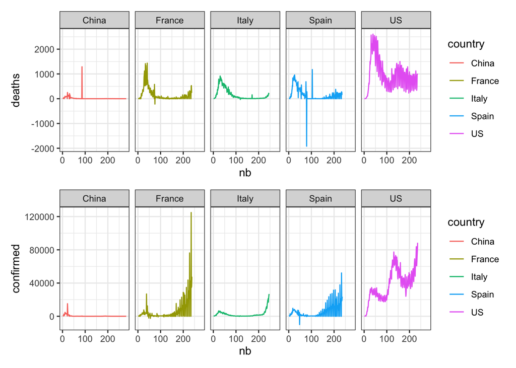

```r
##without log
P1d <- alldataplot1 %>% ggplot(aes(x=nb, y=confirmed,color=country)) + geom_line() + facet_grid(cols = vars(country))

P1c <- alldataplot1 %>% ggplot(aes(x=nb, y=deaths,color=country)) + geom_line() + facet_grid(cols = vars(country))

P1 <- P1c / P1d

P1
```

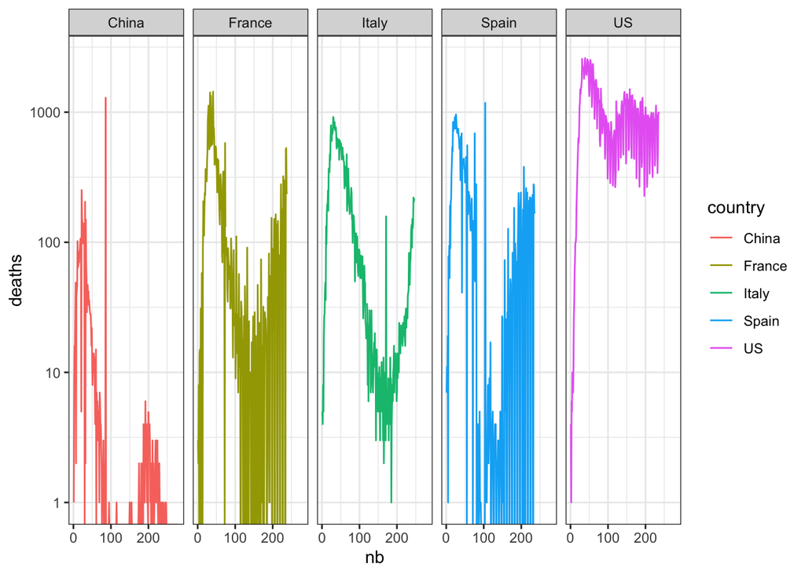

```r
##with log
P1d <- alldataplot1 %>% ggplot(aes(x=nb, y=deaths,color=country)) + geom_line() + scale_y_log10() + facet_grid(cols = vars(country))
P1d
```

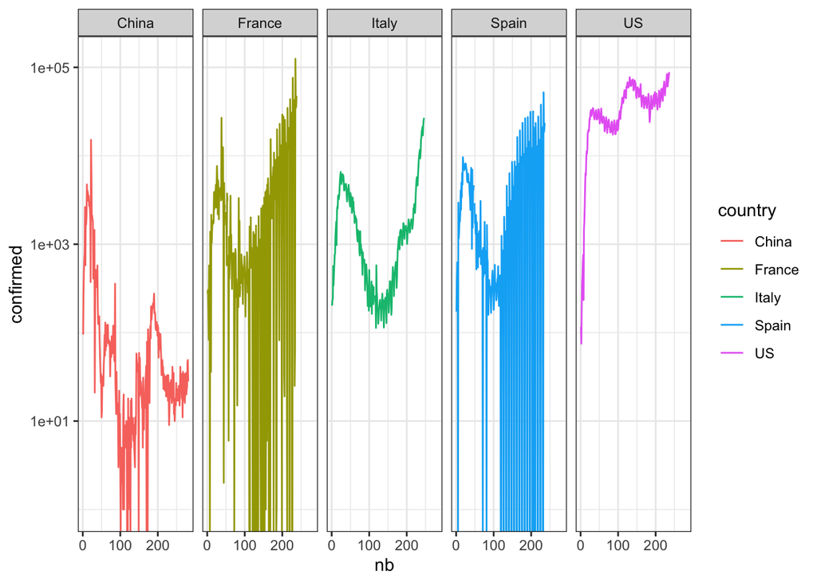

```r
P1c <- alldataplot1 %>% ggplot(aes(x=nb, y=confirmed,color=country)) + geom_line() + scale_y_log10() + facet_grid(cols = vars(country))
P1c
```

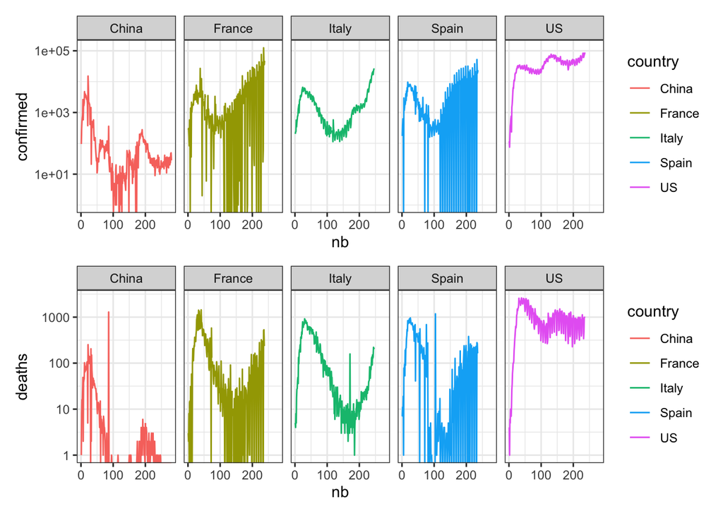

```r
P1 <- P1c / P1d
P1
```

- Plot (P2) the death ratio per country (averaged over time)
  - is there anything wrong?

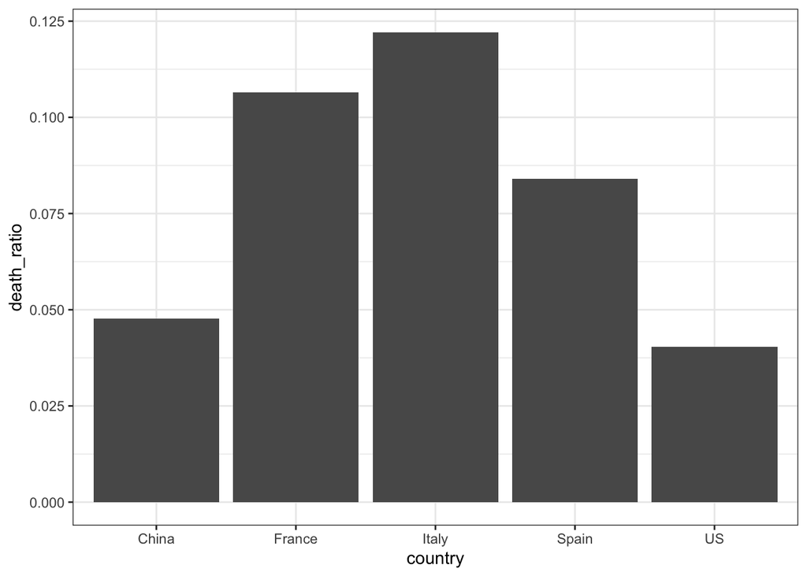

```r
alldataplot2 <- alldataplot1 %>% group_by(country) %>% mutate(death_ratio = sum(cumul_deaths/cumul_confirmed)/length(date)) %>% filter(date == max(date))

P2 <- alldataplot2 %>% ggplot(aes(y=death_ratio,x=country)) + geom_bar(stat = "identity")

P2
```

```r
#The death ratios in Italy and France seem to be too big compared to the real one. Actually here we are only taking into account the confirmed case in each country and not the real number of cases. For example in France we may have tested only a small percentage of the population during a few weeks whereas other countries (like China) may have tested a greater percentage of the population each day after the first confirmed cases. This would imply that the real death ratio formula is : death_ratio = deaths / (confirmed_cases + non_tested_covid_positive_people)
```

- To better see the effect of confinement regulation, it’s probably more interesting to plot the number of new confirmed cases. Plot as a barplot the number of new confirmed cases per day for 2 countries of your choice, and add a vertical line corresponding to the date of application of confinement rules.

[figure not shown]

```r
## confinement regulation in Italy -> 2020-03-09
## confinement regulation in Spain -> 2020-03-15

alldataplotI <- alldata %>% filter(country == "Italy")
P1I <- alldataplotI %>% ggplot(aes(x = date, y = confirmed)) + geom_bar(stat = "identity") + geom_vline(xintercept = mdy("03/09/20") ) + ggtitle("France")
P1I
```

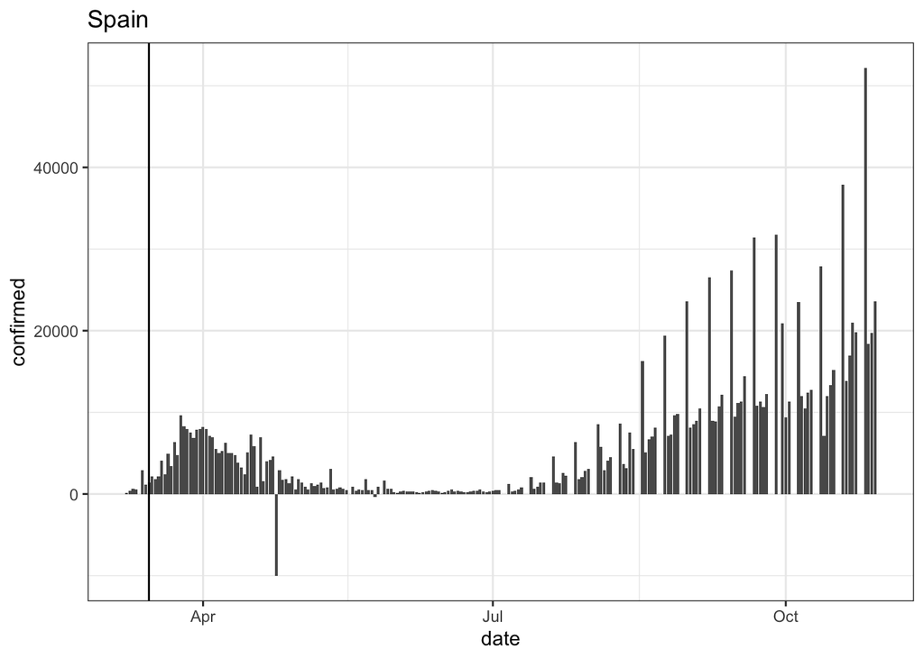

```r
alldataplotS <- alldata %>% filter(country == "Spain")
P1S <- alldataplotS %>% ggplot(aes(x = date, y = confirmed)) + geom_bar(stat = "identity") + geom_vline(xintercept = mdy("03/15/20") ) + ggtitle("Spain")
P1S
```

[figure not shown]

```r
P3 <- P1I / P1S
P3
```

# 3 Fitting

- Load the library `broom` ([vignette](https://cran.r-project.org/web/packages/broom/vignettes/broom.html)). `broom` allows tidying the output of fit functions such as `lm()` or `nls()`, taking the text output and making it into a tibble. Example:

```r
library(broom)
library(tidyverse)
library(ggplot2)
theme_set(theme_bw())
# Create fake data
a <- seq(-10,10,1)
d <- tibble(x=rep(a,3),
            y=c(a*runif(1)+runif(length(a)),
                a*runif(1)+1+runif(length(a)),
                a*runif(1)+2+runif(length(a))),
            T=factor(rep(1:3,each=length(a)))
            )
# Fit the data using nls() by nesting
d_fit <- d %>%
    nest(data=-T) %>%
    mutate(fit=map(data, ~ nls(data = .,
                   y~x*A+B,
                   start=list(A=1, B=1))),
           tidied = map(fit, tidy),
           augmented = map(fit, augment))
d_fit
```

```
## # A tibble: 3 x 5
##   T     data              fit    tidied           augmented
##   <fct> <list>            <list> <list>           <list>
## 1 1     <tibble [21 × 2]> <nls>  <tibble [2 × 5]> <tibble [21 × 4]>
## 2 2     <tibble [21 × 2]> <nls>  <tibble [2 × 5]> <tibble [21 × 4]>
## 3 3     <tibble [21 × 2]> <nls>  <tibble [2 × 5]> <tibble [21 × 4]>
```

```r
d_fit %>% unnest(augmented)
```

```
## # A tibble: 63 x 8
##    T     data              fit    tidied               x      y .fitted  .resid
##    <fct> <list>            <list> <list>           <dbl>  <dbl>   <dbl>   <dbl>
##  1 1     <tibble [21 × 2]> <nls>  <tibble [2 × 5]>   -10 -6.33   -6.02  -0.318
##  2 1     <tibble [21 × 2]> <nls>  <tibble [2 × 5]>    -9 -5.66   -5.37  -0.291
##  3 1     <tibble [21 × 2]> <nls>  <tibble [2 × 5]>    -8 -4.27   -4.73   0.460
##  4 1     <tibble [21 × 2]> <nls>  <tibble [2 × 5]>    -7 -4.42   -4.09  -0.329
##  5 1     <tibble [21 × 2]> <nls>  <tibble [2 × 5]>    -6 -3.14   -3.44   0.308
##  6 1     <tibble [21 × 2]> <nls>  <tibble [2 × 5]>    -5 -2.20   -2.80   0.602
##  7 1     <tibble [21 × 2]> <nls>  <tibble [2 × 5]>    -4 -2.35   -2.16  -0.193
##  8 1     <tibble [21 × 2]> <nls>  <tibble [2 × 5]>    -3 -1.42   -1.52   0.0976
##  9 1     <tibble [21 × 2]> <nls>  <tibble [2 × 5]>    -2 -0.602  -0.873  0.271
## 10 1     <tibble [21 × 2]> <nls>  <tibble [2 × 5]>    -1 -0.256  -0.230 -0.0260
## # … with 53 more rows
```

```r
d_fit %>% unnest(tidied)
```

```
## # A tibble: 6 x 9
##   T     data      fit    term  estimate std.error statistic  p.value augmented
##   <fct> <list>    <list> <chr>    <dbl>     <dbl>     <dbl>    <dbl> <list>
## 1 1     <tibble … <nls>  A        0.643   0.0104      62.0  2.14e-23 <tibble [2…
## 2 1     <tibble … <nls>  B        0.413   0.0628       6.58 2.68e- 6 <tibble [2…
## 3 2     <tibble … <nls>  A        0.436   0.00884     49.4  1.57e-21 <tibble [2…
## 4 2     <tibble … <nls>  B        1.42    0.0535      26.6  1.74e-16 <tibble [2…
## 5 3     <tibble … <nls>  A        0.873   0.0101      86.5  3.93e-26 <tibble [2…
## 6 3     <tibble … <nls>  B        2.59    0.0611      42.4  2.78e-20 <tibble [2…
```

```r
d_fit %>% unnest(tidied) %>%
  select(T, term, estimate, std.error) %>%
  pivot_wider(names_from = term,
              values_from = c(estimate,std.error))
```

```
## # A tibble: 3 x 5
##   T     estimate_A estimate_B std.error_A std.error_B
##   <fct>      <dbl>      <dbl>       <dbl>       <dbl>
## 1 1          0.643      0.413     0.0104       0.0628
## 2 2          0.436      1.42      0.00884      0.0535
## 3 3          0.873      2.59      0.0101       0.0611
```

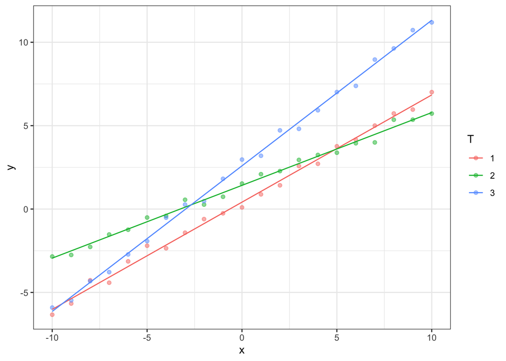

```r
ggplot(data=d, aes(x=x, y=y, col=T))+
    geom_point(alpha=0.5) +
    geom_line(data=d_fit %>% unnest(augmented),
        aes(x=x,y=.fitted, col=T))
```

Here, by combining `nest()` and `purrr::map()`, we can apply the fit to each group. The result is a tibble containing the fit result for each group. Then, using `broom`’s function `augment()` and `tidy()`, we respectively get the fitted values and residues, and the fitting parameters.

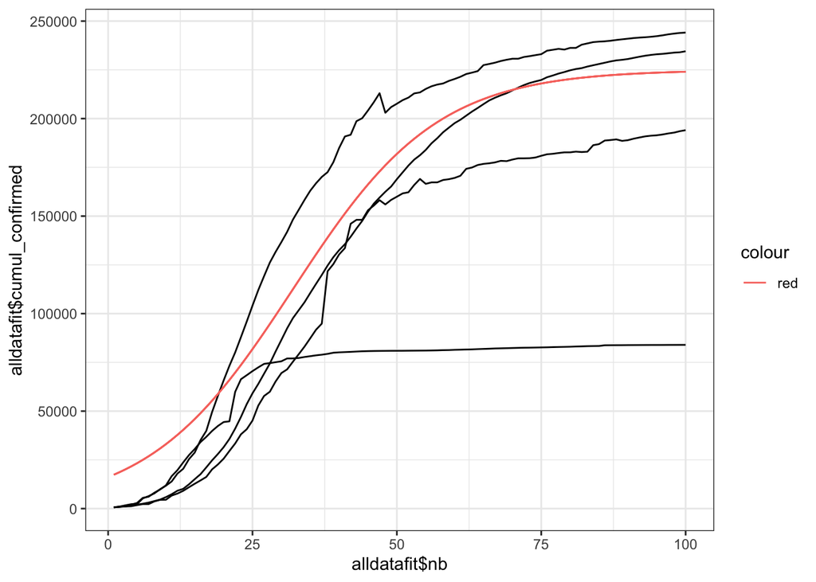

```r
library(broom)
logical <- function(x,L,k,xO){
  L/(1+exp(-k*(x-xO)))
}

##on garde les 100 premières valeurs (100 premiers jours depuis la premiere infection respective dans chaque pays)
alldatafit <- alldata %>% filter(country == "France" | country == "Italy" | country == "Spain" | country == "China") %>% group_by(country) %>% slice(1:100)

##j'essaye d'intuiter les valeurs des paramètres
alldatafit %>% ggplot(aes(x = alldatafit$nb, y = alldatafit$cumul_confirmed, colors = alldatafit$country)) + geom_line() + geom_line(aes(x = alldatafit$nb,y = logical(alldatafit$nb,225000,0.08,32), color = "red"))
```

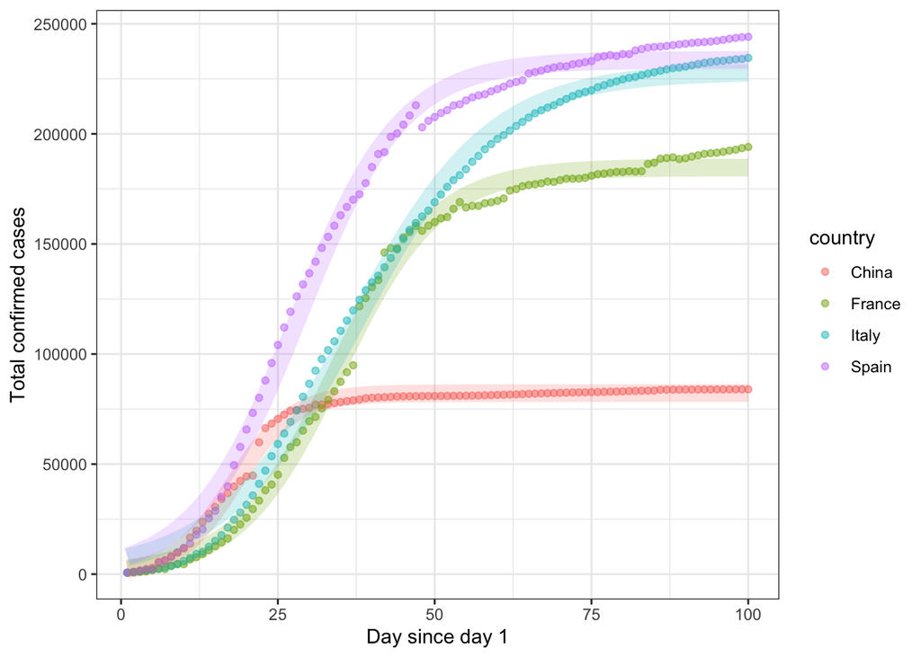

```r
##on fait le fit
d_fit <- alldatafit[,-c(2,4:6)] %>%
  nest(data=-country) %>%
    mutate(fit=map(data,~ nls(data = .,cumul_confirmed~logical(nb,L,k,xO),
                   start=list(L=max(.$cumul_confirmed), k=0.1, xO = 30))),
           tidied = map(fit, tidy),
           augmented = map(fit, augment))

ggplot(data=alldatafit, aes(x=nb, y=cumul_confirmed, color=country))+
    geom_point(alpha=0.5) +
    geom_line(data=d_fit %>% unnest(augmented),
        aes(x=nb,y=.fitted, col=country, size = 1), alpha = 0.2, show.legend = FALSE) +
    xlab("Day since day 1") + ylab("Total confirmed cases")
```